# EE 046746 - Technion - Computer Vision

## Tutorial 06 - Homography, Alignment & Panoramas

[figure not shown]

## Agenda

- Matching Local Features
- Parametric Transformations
- Computing Parametric Transformations
  - Affine
  - Projective
  - Excercise 1 (Spring 2020 Q1A))
- RANSAC
  - Excercise 2 (Spring 2020 Q1D) - Ransac---Ransac)
- Panorama
  - Warping
    - Excercise 3 (Spring 2020 Q1B))
  - Image Blending (Feathering)
- Kornia & Transformations in Deep Learning
- Recommended Videos
- Credits

The largest panorama in the world (2014): Mont Blanc

In2WHITE Video

[In2WHITE Full Image](http://www.in2white.com/)

Homographic usage examples:

http://blog.flickr.net/en/2010/01/27/a-look-into-the-past/

https://www.instagram.com/albumplusart/

```python
%%html
<iframe src="http://www.in2white.com/" width="700" height="600"></iframe>
```

[interactive chart not shown]

### Matching Local Features

#### Feature matching

- We know how to detect and describe good points
- Next question: How to match them?

[figure not shown]

#### Typical feature matching results

- Some matches are correct
- Some matches are incorrect

[figure not shown]

- Solution: search for a set of geometrically consistent matches

### Parametric Transformations

#### Image Alignment

Given a set of matches, what parametric model describes a geometrically consistent transformation?

[figure not shown]

#### Basic 2D Transformations

[figure not shown]

### Parametric (Global) Warping

Examples of parametric warps:

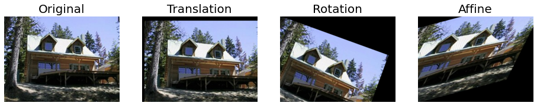

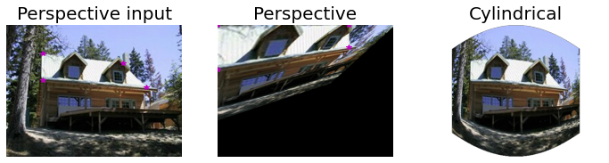

```python
plot_images(img,Titles,(1,4),figsize=(16,4),fontsize=20)

plt.figure(figsize=(12,4))
plt.subplot(131)
plt.imshow(im),plt.title('Perspective input',fontsize=20)
plt.plot(pts1[:,0],pts1[:,1],'m*')
plt.axis('off')
plt.subplot(132),plt.imshow(im_perspective),plt.title('Perspective',fontsize=20)
plt.plot(pts2[:,0],pts2[:,1],'m*')
plt.axis('off')
plt.subplot(133),plt.imshow(img_cyl)
plt.title('Cylindrical',fontsize=20)
_ = plt.axis('off')
```

### Basic 2D Transformations

[figure not shown]

#### When can we use a homography matrix to describe the transformation of the scene?

Homography maps between:

- Points that lay on a plane in the real world and their positions in an image.
- Points in two different images that lay on the **same** plane.
- Two images of a 3D object where the camera has been rotated but has not been translated.

Homographies are used to approximate the transformations of far away objects:

- Works fine for small viewpoint changes.

### Excercise 1 (Spring 2020 Q1A)

#### Write down the homography H ($3x3$), that maps from image-1 to image-2 in the following cases:

1. Image-2 is a translated image 1 by 100 pixels to the left.
2. Image-2 is a $3\times$ zoom of image 1, so that the pixel indexed $(0,0)$ stays in its original position.

#### Answer:

1. Image-2 is a translated image 1 by 100 pixels to the left.

We know that for a translation the homography matrix becomes: $$\begin{bmatrix} 1 & 0 & t_x\\ 0 & 1 & t_y \\ 0 & 0 & 1 \end{bmatrix}$$

The translation of the image is to the left, which means $$x_2 = x_1 -100$$ and the position in the $y$ axis stays the same: $$y_2 = y_1$$

Therefore, the homography that describes the given translation is given by: $$\begin{bmatrix} 1 & 0 & -100\\ 0 & 1 & 0 \\ 0 & 0 & 1 \end{bmatrix}$$

Sanity check: $$\begin{bmatrix} x_2\\ y_2 \\1 \end{bmatrix}=\begin{bmatrix} 1 & 0 & -100\\ 0 & 1 & 0 \\ 0 & 0 & 1 \end{bmatrix}\begin{bmatrix} x_1\\ y_1 \\1 \end{bmatrix} = \begin{bmatrix} x_1 - 100\\ y_1 \\1 \end{bmatrix}$$

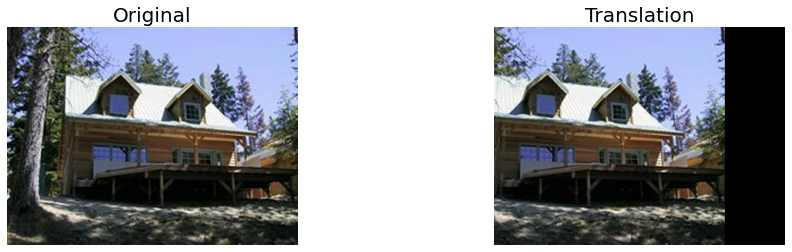

```python
im = cv2.imread('./assets/tut_8_exm.jpg')
im = cv2.cvtColor(im,cv2.COLOR_BGR2RGB)
rows,cols,d = im.shape
h_T = np.float32([[1, 0, -100],
                  [0, 1, 0],
                  [0, 0, 1]])
im_T = cv2.warpPerspective(im, h_T,(cols,rows))
Titles = ['Original','Translation']

plot_images([im,im_T],Titles,(1,2),figsize=(16,4),fontsize=20)
```

1. Image-2 is a $3\times$ zoom of image 1, so that the pixel indexed $(0,0)$ stays in its original position.

#### Answer:

The scaled image is different by 1 DOF, since we scale the X-axis and the Y-axis the same amount (same zoom). Going back to the homography matrix, this means only the $s$ parameter changes:

$$\begin{bmatrix} 3 & 0 & 0\\ 0 & 3 & 0 \\ 0 & 0 & 1 \end{bmatrix}$$

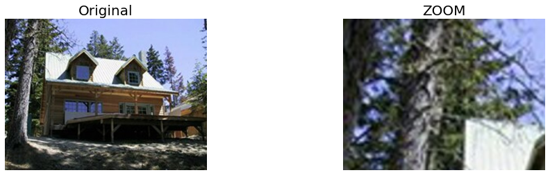

```python
h_S = np.float32([[3,0,0],[0,3,0],[0,0,1]])
im_S = cv2.warpPerspective(im, h_S,(cols,rows))
Titles = ['Original','ZOOM']

plot_images([im,im_S],Titles,(1,2),figsize=(16,4),fontsize=20)
```

### Computing Parametric Transformations

- Affine
- Projective

#### Computing Affine Transformation

- Assuming we know correspondences, how do we get the transformation?

$$ \begin{bmatrix} x_i' \\ y_i' \\ 1 \end{bmatrix}= \begin{bmatrix} h_1 & h_2 & h_3\\ h_4 & h_5 & h_6 \\ 0 & 0 & 1 \end{bmatrix} \begin{bmatrix} x_i \\ y_i \\ 1 \end{bmatrix}$$$$ \begin{bmatrix} \dots \\ x_i' \\ y_i' \\ \dots \end{bmatrix}= \begin{bmatrix} &&\dots\\ x_i & y_i & 1 & 0 & 0 & 0 \\ 0&0&0&x_i&y_i&1 \\ &&\dots \end{bmatrix} \begin{bmatrix} h_1\\h_2\\h_3\\ h_4 \\ h_5 \\ h_6 \\ \end{bmatrix} $$$$b = Ah$$

- Solve with Least-squares $||Ah-b||^2$ $$h = (A^TA)^{-1}A^Tb$$ In Python:

`A_inv = pinv(A)`

`h = np.linalg.pinv(A)@b`

- How many matches (correspondence pairs) do we need to solve?
- Once we have solved for the parameters, how do we compute the coordinates of the corresponding point for any pixel $(x_{new},y_{new})$?

$$ H = \begin{bmatrix} h_1 & h_2 & h_3\\ h_4 & h_5 & h_6 \\ 0 & 0 & 1 \end{bmatrix} $$$$x'_{new} = Hx_{new}$$

#### Computing Projective Transformation

- Recall working with homogenous coordinates

$$ \begin{bmatrix} u_i \\ v_i \\ w_i \end{bmatrix}= \begin{bmatrix} h_1 & h_2 & h_3\\ h_4 & h_5 & h_6 \\ h_7 & h_8 & h_9 \end{bmatrix} \begin{bmatrix} x_i \\ y_i \\ 1 \end{bmatrix} $$$$ x_i' = u_i/w_i$$

$$y_i' = v_i/w_i$$

- We get the following non-linear equation:

$$ x_i' = \frac{h_1x_i + h_2 y_i + h_3}{h_7x_i+h_8y_i+h_9}$$

$$y_i' = \frac{h_4x_i + h_5 y_i + h_6}{h_7x_i+h_8y_i+h_9}$$

- We can re-arrange the equation

$$ \begin{bmatrix} &&&&&\dots\\ x_i & y_i & 1 & 0 & 0 & 0 & -x_ix_i'&-y_ix_i'& -x_i' \\ 0&0&0&x_i&y_i&1 & -x_iy_i'&-y_iy_i'& -y_i' \\ &&&&&\dots \end{bmatrix} \begin{bmatrix} h_1\\h_2\\h_3\\ h_4 \\ h_5 \\ h_6 \\ h_7\\h_8\\h_9\\ \end{bmatrix} = \begin{bmatrix} \dots \\ 0 \\ 0 \\ \dots \end{bmatrix}$$

- We want to find a vector $h$ satisfying

$$Ah=0$$

where A is full rank. We are obviously not interested in the trivial solution $h=0$ hence we add the constraint $$||h||=1$$

- Thus, we get the homogeneous Least square equation:

$$ arg\min_h{||Ah||_2^2} \text{, } s.t ||h||_2^2=1 $$

Compute Projective transformation using SVD: $$arg \min_h{||Ah||_2^2} \text{, } s.t ||h||_2^2=1 $$

- Let decompose $A$ using SVD: $ A = UDV^T $, where $U$ and $V$ are orthonomal matrix, and $D$ is a diagonal matrix.
  - Need a reminder on SVD? [Click Here](https://nbviewer.jupyter.org/github/taldatech/cs236756-intro-to-ml/blob/master/cs236756_tutorial_03_linear_algebra.ipynb)
- From orthonormality of $U$ and $V$:

$$ ||UDV^Th||=||DV^Th||$$$$ ||V^Th||=||h|| $$

Hence, we get the following minimization problem:

$$ arg \min_h||DV^Th|| \text{ s.t. } ||V^Th||=1 $$

- Subsitute $y=V^Th$: $$ arg \min_h||Dy|| \text{ s.t. } ||y||=1 $$
- $D$ is a diagonal matrix with decreasing values. Then, it is clear that $y=[0,0,\dots,1]^T$.
- Therefore, choosing $h$ to be the last column in $V$ will minimize the equation.

In Python:

`(U,D,Vh) = np.linalg.svd(A,False)`

`h = Vh.T[:,-1]`

#### Some more options to find $h$:

- Lagrange multipliers - [Least–squares Solution of Homogeneous Equations](http://cmp.felk.cvut.cz/cmp/courses/XE33PVR/WS20072008/Lectures/Supporting/constrained_lsq.pdf)
- Using EVD (eigenvalue decomposition) on $A^TA$.
- If we know our transformation is nearly Affine we can get an approximate solution using linear least squares
- As we said, some of the points may be a good match, and some won't.
- If we use a wrong point in the algorithm, we will get the wrong transformation.
- How can we solve that major problem?
- We can use our prior knowledge on the type of the trasformation, and use points that have strong evidence that are correct.
- For example, we know that homographys preserve lines, so we can try to look for keypoints that lay in a line, and use them to find the transformation.
- How would we find keypoints that lay on a line?

## RANSAC

#### RANdom SAmple Consensus [Fischler & Bolles 1981]

- Key ideas:
  - Look for “inliers” and use only them
  - If we fit a model to “outliers” we will not get a good fitting

#### RANSAC Algorithm

*Loop*:

1. Randomly select a group of points
2. Fit a model to the selected group
3. Find the inliers of the computed model
4. If number of inliers is large enough re-compute model using only inliers
5. Compute number of inliers of updated model

**The winner**: model with the largest number of inliers

#### Line Fitting with RANSAC

- Input: A set of edge points

[figure not shown]

- **Step 1**: Select two points

[figure not shown]

- **Step 2**: Fit a line to the selected points

[figure not shown]

- **Step 3**: Identify inliers

[figure not shown]

- **Step 4**: Repeat Steps 1-3 until convergence
- **Iteration 2**: Steps 1-2:
  - Sample new pts and fit a line

[figure not shown]

- **Iteration 2**: Step 3:
  - Count number of new inliers

[figure not shown]

#### RANSAC – Stopping Criteria

- **Option 1**: when the model is good enough:
  - By the number of inliers
  - By its fitting error
- **Option 2**: according to probability
  - Let $K$ be the number of iterations
  - Let $n$ be the number of points needed to compute the model
  - Let $f$ be the fraction of inliers of a model
  - Then the probability that a single sample is correct: $f^n$
  - The probability that all $K$ samples fail is $(1−f^n)^K$
  - Choose $K$ high enough to keep the failure rate low enough

#### RANSAC – For Multiple Models?

- How can we use RANSAC to compute multiple models?
  - Apply RANSAC multiple times, each time we remove the detected inliers.

#### RANSAC - Summary

- **Pros**
  - General method that works well for lots of model fitting problems
  - Easy to implement
- **Cons**
  - When the percentage of outliers is high too many iterations are needed and failure rate increases
- **Implementation**
  - OpenCV usage with Homographies (Tutorial 7): `cv2.findHomography(src_pts, dst_pts, cv2.RANSAC)`
  - Scikit-image: `skimage.measure.ransac()`
  - Scikit-learn: `sklearn.linear_model.RANSACRegressor()`
  - and many more..

Many improved algorithms:

- [PROSAC](https://dspace.cvut.cz/bitstream/handle/10467/9496/2005-Matching-with-PROSAC-progressive-sample-consensus.pdf;jsessionid=AB7FDDCCABE0CA249D253E7E8F9D1DC7?sequence=1)
  - Key idea is to assume that the similarity measure predicts correctness of a match
- [Randomized RANSAC](http://www.bmva.org/bmvc/2002/papers/50/full_50.pdf)
  - Each step take a random subset of the query points and perform RANSAC
- [KALMANSAC](https://ieeexplore.ieee.org/abstract/document/1541313)
- [and more...](https://en.wikipedia.org/wiki/Random_sample_consensus#Development_and_improvements)
- Estimating homogrpahy with RANSAC in OpenCV: `cv2.findHomography(src_pts, dst_pts, cv2.RANSAC)`

### Excercise 2 (Spring 2020 Q1D) - Ransac

We'd like to fit an ellipse to a given set of 200 points, $X_i = (x_i,y_i), i=1,...,200$.  
As you know, an ellipse can be described by the implicit equation $a^T(x^2,xy,y^2,x,y,1)=0$ where $a = (a_1, a_2, a_3, a_4, a_5, a_6)$ is a coefficients vector. The data points might be noisy, such that some of the points may not reside on the perimeter of the ellipse (outliers).

- Describe the RANSAC algorithm needed to fit the ellipse (and find $a$).

#### Answer:

- to define an ellipse, we need at least 5 points ([Why?](http://www.lee-mac.com/5pointellipse.html#:~:text=Five%20points%20are%20required%20to%20define%20a%20unique%20ellipse)). This means $a$ is defined up to a scale factor.

**Step 1**: Sample 5 points from $X_i$ randomly. **Step 2**: Fit an ellipse to the points with Least Squares.

- $$ \begin{bmatrix} &&\dots\\ x_i^2 & x_iy_i & y_i^2 & x_i &y_i & 1 \\ &&\dots \end{bmatrix}\begin{bmatrix}a_1 \\ a_2 \\ a_3 \\ a_4\\a_5\\a_6\end{bmatrix} =0$$
- This can be denoted as $Sa=0$, and solved via SVD under the constraint $||a||=1$

**Step 3**: Find the points that fit to the model (inliers), i.e. points with a fit error below a threshold chosen in advanced.  
**Step 4**: Refine our model according to all the inliers, and count them. The number of inliers is the "score" of the current model (from this iteration).  
**Step 5**: Repeat 1-4, until the stop criteria has been met.

When do we stop?

- The percentage of inliers out of all the points is above a certain percentage.
- The amount of inliers is above a certain amount.
- An error threshold (for the LS) is reached.
- A predefined amount of iterations is reached.

#### application 1: Planting images into other images

[figure not shown]

#### application 2: BirdEye

[figure not shown]

- [Image Source](https://csyhhu.github.io/2015/07/09/IPM/)

#### application 3: Looking into the past

[figure not shown]

- Image Source from Flickr

#### application 4: Panorama

[figure not shown]

Obtain a wider angle view by combining multiple images

## Panorama

- Warping
- Image Blending (Feathering)

[figure not shown]

### Warp - What we need to solve?

- Given source and target images, and the transformation between them, how do we align them?
- Send each pixel $x$ in image1 to its corresponding location $x’$ in image 2

[figure not shown]

#### Forward Warping

- What if pixel lands “between” two pixels?
- Answer: add “contribution” to several pixels and normalize (splatting)

[figure not shown]

- Limitation: Holes (some pixels are never visited)

[figure not shown]

#### Inverse Warping

- For each pixel x’ in image 2 find its origin x in image 1
- Problem: What if pixel comes from “between” two pixels?

[figure not shown]

- Answer: interpolate color value from neighbors

[figure not shown]

##### Bilinear Interpolation

Sampling at $f(x,y)$:

[figure not shown]

$$ f(x,y) = (1-a)(1-b) f[i,j]\\ + a(1-b) f[i+1,j]\\ + ab f[i+1,j+1]\\ +(1-a)b f[i,j+1]\\ $$

Python:

- `interp2d()` - https://docs.scipy.org/doc/scipy/reference/generated/scipy.interpolate.interp2d.html
- Inverse warping in OpenCV: `cv2.warpPerspective(im,*,*,cv2.WARP_INVERSE_MAP)`

### Excercise 3 (Spring 2020 Q1B)

1. Describe forward and backward wraping.
2. For which out of the two cased before will there be a difference between using inverse or forward warping?
3. For the case which a difference exists, what type of warping should be used and why?

reminder:

- Image-2 is a translated image 1 by 100 pixels to the left
- Image-2 is a 3x zoom of image 1, so the index (0,0) stay in place

#### Answer

1. Read the tutorial :)
2. For the translation there will be no difference between forward/inverse warping, while for the zooming there will be a difference - we'll get holes.

1. The backward wraping will be of course better, since as we saw no holes will be created.

```python
import numpy as np
from scipy import interpolate
import matplotlib.pyplot as plt

# original samples
x = np.arange(-5.01, 5.01, 0.25)
y = np.arange(-5.01, 5.01, 0.25)
xx, yy = np.meshgrid(x, y)
z = np.sin(xx**2+yy**2)

# interpolated samples
xnew = np.arange(-5.01, 5.01, 1e-2)
ynew = np.arange(-5.01, 5.01, 1e-2)
```

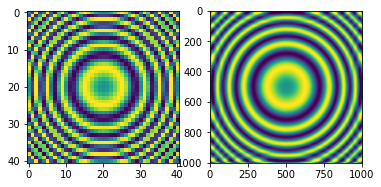

```python
## Cubic
f = interpolate.interp2d(x, y, z, kind='cubic')
znew = f(xnew, ynew)

plt.figure()
plt.subplot(121)
plt.imshow(z,vmin=-1,vmax=1)
plt.subplot(122)
plt.imshow(znew,vmin=-1,vmax=1)
plt.show()
```

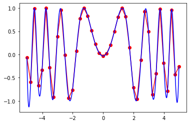

```python
plt.figure()
plt.plot(x, z[0, :], 'ro-', xnew, znew[0, :], 'b-')
plt.show()
```

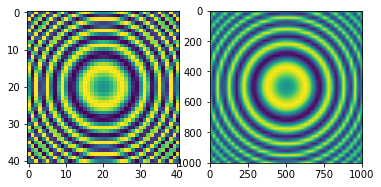

```python
##linear
f2 = interpolate.interp2d(x, y, z, kind='linear')
znew2 = f2(xnew, ynew)

plt.figure()
plt.subplot(121)
plt.imshow(z,vmin=-1,vmax=1)
plt.subplot(122)
plt.imshow(znew2,vmin=-1,vmax=1)
plt.show()
```

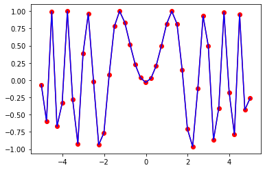

```python
plt.figure()
plt.plot(x, z[0, :], 'ro-', xnew, znew2[0, :], 'b-')
plt.show()
```

### Image Blending

[figure not shown]

- Alpha blending
- Pyramid blending

##### Alpha Blending

[figure not shown]

##### Pyramid Blending:

1. Build a Gaussian pyramid for each image
2. Build the Laplacian pyramid for each image
3. Decide/find the blending border (in the example: left half belongs to image 1, and right half to image 2 -> the blending border is `cols/2`)
   - Split by index, or
   - Split using a 2 masks (can be weighted masks)
4. Constract a new mixed pyramid - mix each level seperatly acording to (3)
5. Reconstract a blend image from the mixed pyramid

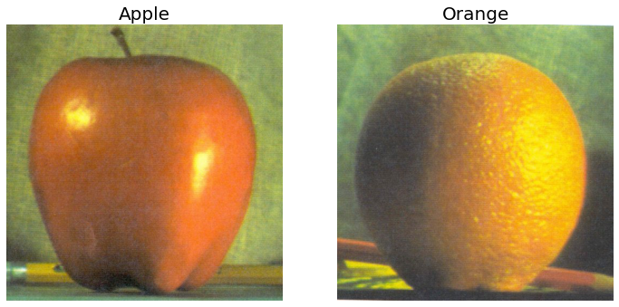

```python
plot_images([A_,B_],['Apple','Orange'],(1,2),figsize=(12,12),fontsize=20)
```

[figure not shown]

```python
plot_images([real,ls_],['Original','Pyramid Blend'],(1,2),figsize=(12,12),fontsize=20)
```

- Alpha blending example:

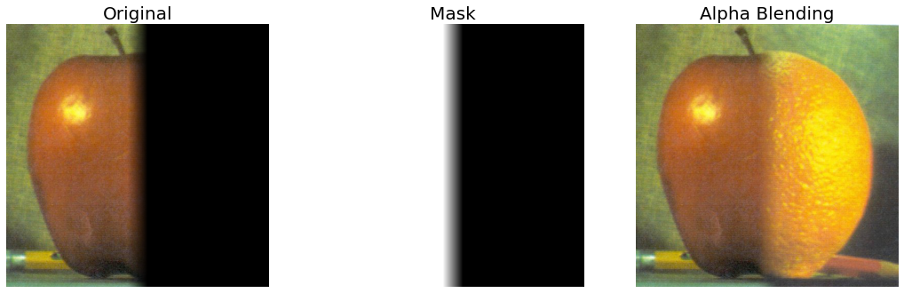

```python
plot_images([real,MASK,ls_],['Original','Mask','Alpha Blending'],(1,3),figsize=(18,12),fontsize=20)
```

- Stylize image using pyramids:

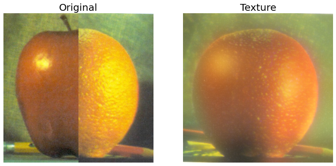

```python
plot_images([real,ls_],['Original','Texture'],(1,2),figsize=(12,12),fontsize=20)
```

##### Blending Improvments

- Many algorithms have different variations of combining alpha and pyramid blending (different masks for different frequencies)
- Find the boundaries using **segmentation**

### Panorama - Summary

- Detect features
- Compute transformations between pairs of frames
- Can Refine transformations using RANSAC
- Warp all images onto a single coordinate system
- Find mixing borders (e.g. using segmentation)
- Blend

## Transformations in Deep Learning

- Can we incorporate transformations in the pipeline of a deep learning algorithm?
  - Moreover, can we accelerate these transformations by performing them on a GPU?
- **YES!**

### Kornia - Computer Vision Library for PyTorch

- [Kornia is a differentiable computer vision library for PyTorch](https://github.com/kornia/kornia)
  - That means you can have gradients for the transformations!
- Inspired by OpenCV, this library is composed by a subset of packages containing operators that can be inserted within neural networks to train models to perform image transformations, epipolar geometry, depth estimation, and low-level image processing such as filtering and edge detection that operate directly on tensors.
- Check out `kornia.geometry` - https://kornia.readthedocs.io/en/latest/geometry.html
- [Warp image using perspective transform](https://kornia.readthedocs.io/en/latest/tutorials/warp_perspective.html)

[figure not shown]

### Recommended Videos

#### Warning!

- These videos do not replace the lectures and tutorials.
- Please use these to get a better understanding of the material, and not as an alternative to the written material.

#### Video By Subject

- Homography
  - Image geometry and planar homography - [ENB339 lecture 9: Image geometry and planar homography](https://www.youtube.com/watch?v=fVJeJMWZcq8)
  - Homography - [Homography in computer vision explained](https://www.youtube.com/watch?v=MlaIWymLCD8)
- Transformations - [Lect. 5(1) - Linear and affine transformations](https://www.youtube.com/watch?v=4I2S5Xhf24o)
- Matching Local Features
  - SIFT - [CSCI 512 - Lecture 12-1 SIFT](https://www.youtube.com/watch?v=U0wqePj4Mx0)